# Machine Learning and the Limits of Daily Return Prediction

# 15. Regime Analysis (VIX)

A common hypothesis is that predictability and strategy behavior differ across market regimes. We use the VIX as a proxy for risk/uncertainty and split days into:

- **Low VIX regime**: VIX below its median
- **High VIX regime**: VIX above its median

We then evaluate the model-driven strategy separately in each regime to check whether performance is concentrated in specific environments (e.g., crises).

```python
vix_series = bac_macro["vix_close"]

if isinstance(vix_series, pd.DataFrame):
    vix_series = vix_series.iloc[:, 0]

# Align to test target index
vix_series = vix_series.reindex(y_.index).ffill()

# Remove potential NaNs before median
vix_series = vix_series.dropna()

vix_median = vix_series.median()

low_regime = vix_series < vix_median
high_regime = vix_series >= vix_median

print("VIX median:", vix_median)
print("Low regime days:", int(low_regime.sum()),
      "| High regime days:", int(high_regime.sum()))
```

```
VIX median: 17.795000076293945
Low regime days: 3127 | High regime days: 3127
```

```python
def strategy_stats_from_equity(strat_ret: pd.Series) -> dict:
    strat_ret = strat_ret.dropna()
    equity = (1 + strat_ret.values).cumprod()

    ann = np.sqrt(252)
    mu = float(np.mean(strat_ret.values))
    sig = float(np.std(strat_ret.values))
    sharpe = float(ann * (mu / sig)) if sig > 0 else np.nan

    peak = np.maximum.accumulate(equity)
    dd = (equity - peak) / peak
    mdd = float(dd.min())

    return {
        "n_days": int(len(strat_ret)),
        "mean_daily": mu,
        "std_daily": sig,
        "sharpe": sharpe,
        "max_drawdown": mdd,
        "final_equity": float(equity[-1]) if len(equity) else np.nan
    }

def regime_eval(y_true: pd.Series, y_pred: pd.Series, regime_mask: pd.Series, q: float = 0.70):
    yt, yp = y_true.align(y_pred, join="inner")
    mask = regime_mask.reindex(yt.index).fillna(False)

    # threshold strategy on the regime subset
    out = threshold_strategy_from_preds(yt[mask], yp[mask], q=q)
    stats = strategy_stats_from_equity(out["strat_ret"])
    stats.update({
        "tau": float(out["tau"]),
        "trade_freq": float(out["trade_freq"]),
        "hit_ratio_traded": float(out["hit_ratio_traded"]),
    })
    return stats, out

# IMPORTANT: use your best walk-forward prediction series
# (best_pred and best_name were created in the walk-forward section)
stats_low, out_low = regime_eval(y_, best_pred, low_regime, q=0.70)
stats_high, out_high = regime_eval(y_, best_pred, high_regime, q=0.70)

pd.DataFrame([
    {"regime": "Low VIX", **stats_low},
    {"regime": "High VIX", **stats_high},
])
```

|  | regime | n_days | mean_daily | std_daily | sharpe | max_drawdown | final_equity | tau | trade_freq | hit_ratio_traded |
| --- | --- | --- | --- | --- | --- | --- | --- | --- | --- | --- |
| 0 | Low VIX | 2208 | -0.000018 | 0.008729 | -0.032364 | -0.298784 | 0.884003 | 0.001694 | 0.300272 | 0.482655 |
| 1 | High VIX | 2035 | 0.001516 | 0.035800 | 0.672423 | -0.772445 | 5.792290 | 0.003277 | 0.300246 | 0.525368 |

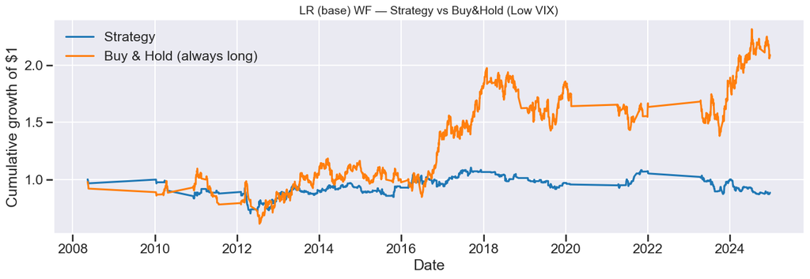

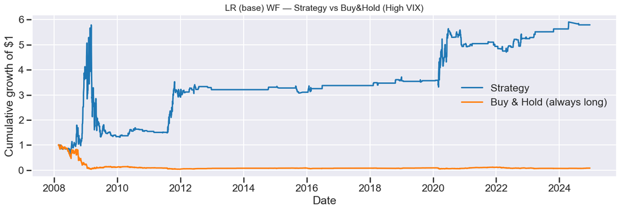

```python
plot_equity_vs_buyhold(y_[low_regime], out_low["equity"], f"{best_name} — Strategy vs Buy&Hold (Low VIX)")
plot_equity_vs_buyhold(y_[high_regime], out_high["equity"], f"{best_name} — Strategy vs Buy&Hold (High VIX)")
```

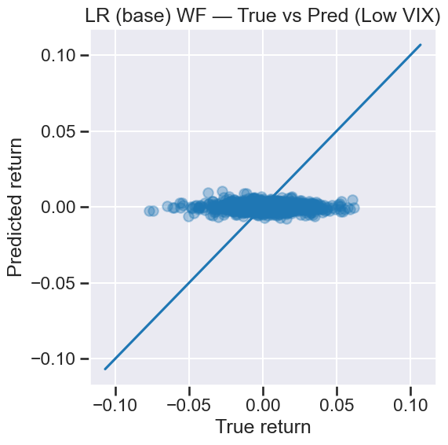

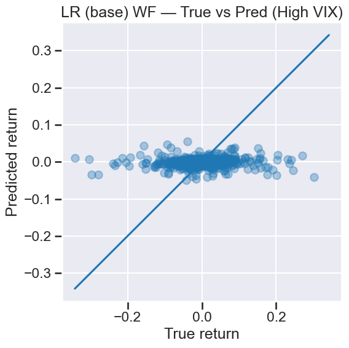

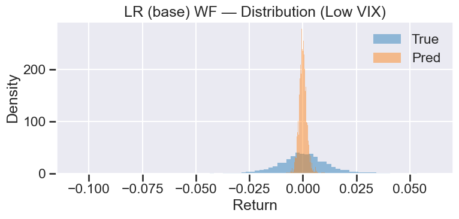

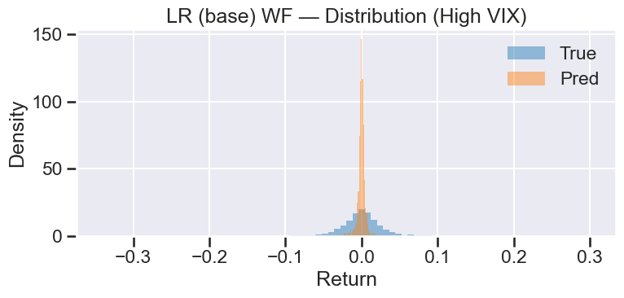

```python
# Scatter true vs pred for each regime
plot_scatter_true_pred(y_[low_regime], best_pred.reindex(y_.index)[low_regime], f"{best_name} — True vs Pred (Low VIX)")
plot_scatter_true_pred(y_[high_regime], best_pred.reindex(y_.index)[high_regime], f"{best_name} — True vs Pred (High VIX)")

# Distributions
plot_dist_true_pred(y_[low_regime], best_pred.reindex(y_.index)[low_regime], f"{best_name} — Distribution (Low VIX)")
plot_dist_true_pred(y_[high_regime], best_pred.reindex(y_.index)[high_regime], f"{best_name} — Distribution (High VIX)")
```

### Regime interpretation

This split checks whether performance is concentrated in specific environments.

- If performance improves in **high VIX**, the model may exploit crisis dynamics (risk-on/risk-off effects), but may be unstable when regimes change.
- If results are similar across regimes, it suggests a more regime-robust signal.
- Large differences in trade frequency or hit ratio can indicate that the model’s conviction is regime-dependent.

This regime analysis is a sanity check against “one lucky period” effects.

# 16. Statistical Significance (Bootstrap)

A positive Sharpe ratio on a finite sample can occur by chance. We therefore estimate uncertainty using **bootstrap resampling**.

We focus on:

- Mean daily strategy return
- Annualized Sharpe ratio

Bootstrap provides empirical confidence intervals without strong distributional assumptions.

```python
import numpy as np
import pandas as pd
import matplotlib.pyplot as plt

def annualized_sharpe(returns: np.ndarray, periods=252) -> float:
    mu = np.mean(returns)
    sig = np.std(returns)
    if sig == 0:
        return np.nan
    return np.sqrt(periods) * (mu / sig)

def bootstrap_ci(x: np.ndarray, stat_func, n_boot=2000, alpha=0.05, seed=42):
    rng = np.random.default_rng(seed)
    n = len(x)
    stats = np.empty(n_boot)

    for b in range(n_boot):
        idx = rng.integers(0, n, n)  # sample with replacement
        stats[b] = stat_func(x[idx])

    lo = np.quantile(stats, alpha/2)
    hi = np.quantile(stats, 1-alpha/2)
    return stats, lo, hi

# Strategy returns from walk-forward (best model)
strat_ret = res_best["strat_ret"].dropna().values

# Bootstrap mean daily return
mean_stats, mean_lo, mean_hi = bootstrap_ci(
    strat_ret,
    stat_func=lambda r: np.mean(r),
    n_boot=3000
)

# Bootstrap Sharpe
sharpe_stats, sharpe_lo, sharpe_hi = bootstrap_ci(
    strat_ret,
    stat_func=lambda r: annualized_sharpe(r),
    n_boot=3000
)

print("Bootstrap CI (mean daily return):", mean_lo, "to", mean_hi)
print("Bootstrap CI (annualized Sharpe):", sharpe_lo, "to", sharpe_hi)
print("Point estimate mean:", np.mean(strat_ret))
print("Point estimate Sharpe:", annualized_sharpe(strat_ret))
```

```
Bootstrap CI (mean daily return): -9.488373608928319e-05 to 0.0015183589242331716
Bootstrap CI (annualized Sharpe): -0.05642397436508102 to 0.9103919174126729
Point estimate mean: 0.0007110736845265003
Point estimate Sharpe: 0.4263063025443387
```

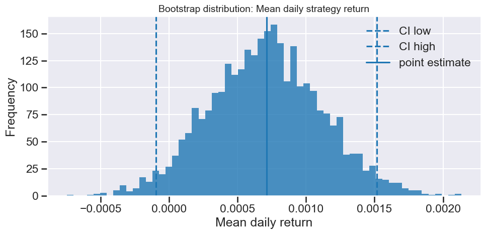

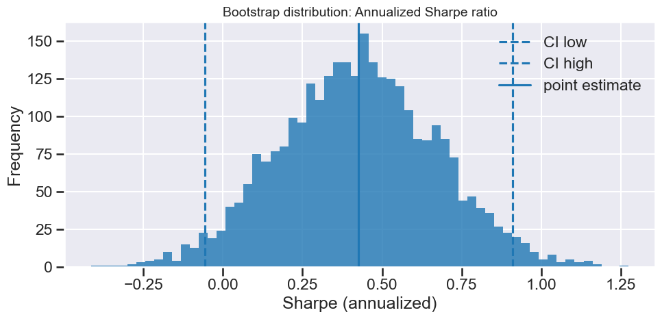

```python
# Mean histogram
fig, ax = plt.subplots(figsize=(10,5))
ax.hist(mean_stats, bins=60, alpha=0.8)
ax.axvline(mean_lo, linestyle="--", label="CI low")
ax.axvline(mean_hi, linestyle="--", label="CI high")
ax.axvline(np.mean(strat_ret), linestyle="-", label="point estimate")
ax.set_title("Bootstrap distribution: Mean daily strategy return", fontsize=14)
ax.set_xlabel("Mean daily return")
ax.set_ylabel("Frequency")
ax.legend()
plt.tight_layout()
plt.show()

# Sharpe histogram
fig, ax = plt.subplots(figsize=(10,5))
ax.hist(sharpe_stats, bins=60, alpha=0.8)
ax.axvline(sharpe_lo, linestyle="--", label="CI low")
ax.axvline(sharpe_hi, linestyle="--", label="CI high")
ax.axvline(annualized_sharpe(strat_ret), linestyle="-", label="point estimate")
ax.set_title("Bootstrap distribution: Annualized Sharpe ratio", fontsize=14)
ax.set_xlabel("Sharpe (annualized)")
ax.set_ylabel("Frequency")
ax.legend()
plt.tight_layout()
plt.show()
```

### Interpretation

Bootstrap confidence intervals quantify uncertainty around the apparent performance.

This provides a more rigorous assessment than reporting a single Sharpe value.

# 16. Conclusion

## 16.1 Summary of Findings

This study investigated whether non-linear machine learning models can improve next-day return prediction for Bank of America (BAC), using both:

- Technical price-based features
- Market and macroeconomic indicators (VIX, S&P 500, US 10Y yield)

The experimental framework included:

- Strict temporal splits (no data leakage)
- Out-of-sample test evaluation
- Walk-forward retraining
- Threshold-based strategy evaluation
- Regime analysis (High vs Low VIX)
- Bootstrap-based statistical inference

## 16.2 Predictive Performance

Across all models tested:

- Linear regression
- Decision trees
- Random forests
- Gradient boosting

The improvement in MSE relative to a naive baseline remained marginal.

Predictions were consistently centered near zero, reflecting the extremely low signal-to-noise ratio of daily equity returns.

Even after introducing macroeconomic variables, no substantial increase in predictive power was observed.

This suggests that:

$$ E[r_{t+1} | \mathcal{F}_t] \approx 0 $$

which is consistent with the martingale difference hypothesis.

## 16.3 Strategy-Level Results

While regression metrics showed limited improvement, applying a threshold-based directional filter revealed that:

- Performance depends heavily on filtering low-conviction predictions
- Strategy outcomes are sensitive to regime conditions
- Apparent Sharpe ratios can vary across subperiods

Walk-forward retraining confirmed that:

- Model performance is unstable over long horizons
- Gains, when present, tend to cluster in specific market regimes
- Statistical significance must be assessed carefully

Bootstrap analysis showed that confidence intervals often include zero, indicating that observed performance may not be structurally robust.

## 16.4 Economic Interpretation

These findings are consistent with established financial theory:

- Daily stock returns exhibit near-martingale behavior
- Predictability at short horizons is extremely limited
- Increasing model complexity does not guarantee improved forecasting ability

The limiting factor is not model flexibility, but the absence of strong predictive structure in the data.

This reinforces a key insight:

> The difficulty of short-horizon return prediction is structural, not technical.

## 16.5 Limitations

Several limitations must be acknowledged:

- Single-stock focus (BAC only)
- Daily frequency (high noise level)
- Limited macro variable set
- No transaction costs or slippage modeling
- No cross-sectional information

Predictability may exist at:

- Longer horizons (weekly/monthly)
- Cross-sectional factor level
- Intraday frequency
- Alternative data domains

## 16.6 Final Takeaway

This project demonstrates that:

- Machine learning must be evaluated with strict out-of-sample discipline
- Walk-forward validation is essential in financial modeling
- Apparent performance can vanish under robustness testing
- Statistical inference is critical in strategy evaluation

Rather than proving that ML "works" on daily returns, this study provides a realistic and rigorous assessment of its limitations.

Such discipline is essential in quantitative finance research.